# Modeling and prediction for movies

## Setup

### Load packages

```r
library(ggplot2)
library(dplyr)
library(statsr)
library(gridExtra)
```

### Load data

```r
load("movies.Rdata")
```

## Part 1: Data

The data consists of 651 randomly sampled movies with release date before 2016. The theater release for these movies ranges from 1970 all the way up to 2014. Given this span of about 44 years, our data sample is representative of the movies produced during that span. So our sample is generalizable.

Moreover, since our data was not part of an experiment (or random assignment for that matter) and it was simply collected, there is no causality.

```r
str(movies)
```

```
## Classes 'tbl_df', 'tbl' and 'data.frame':    651 obs. of  32 variables:
##  $ title           : chr  "Filly Brown" "The Dish" "Waiting for Guffman" "The Age of Innocence" ...
##  $ title_type      : Factor w/ 3 levels "Documentary",..: 2 2 2 2 2 1 2 2 1 2 ...
##  $ genre           : Factor w/ 11 levels "Action & Adventure",..: 6 6 4 6 7 5 6 6 5 6 ...
##  $ runtime         : num  80 101 84 139 90 78 142 93 88 119 ...
##  $ mpaa_rating     : Factor w/ 6 levels "G","NC-17","PG",..: 5 4 5 3 5 6 4 5 6 6 ...
##  $ studio          : Factor w/ 211 levels "20th Century Fox",..: 91 202 167 34 13 163 147 118 88 84 ...
##  $ thtr_rel_year   : num  2013 2001 1996 1993 2004 ...
##  $ thtr_rel_month  : num  4 3 8 10 9 1 1 11 9 3 ...
##  $ thtr_rel_day    : num  19 14 21 1 10 15 1 8 7 2 ...
##  $ dvd_rel_year    : num  2013 2001 2001 2001 2005 ...
##  $ dvd_rel_month   : num  7 8 8 11 4 4 2 3 1 8 ...
##  $ dvd_rel_day     : num  30 28 21 6 19 20 18 2 21 14 ...
##  $ imdb_rating     : num  5.5 7.3 7.6 7.2 5.1 7.8 7.2 5.5 7.5 6.6 ...
##  $ imdb_num_votes  : int  899 12285 22381 35096 2386 333 5016 2272 880 12496 ...
```

[output cut: 18 more lines]

Check for NA values.

```r
summary(movies)
```

```
##     title                  title_type                 genre
##  Length:651         Documentary : 55   Drama             :305
##  Class :character   Feature Film:591   Comedy            : 87
##  Mode  :character   TV Movie    :  5   Action & Adventure: 65
##                                        Mystery & Suspense: 59
##                                        Documentary       : 52
##                                        Horror            : 23
##                                        (Other)           : 60
##     runtime       mpaa_rating                               studio
##  Min.   : 39.0   G      : 19   Paramount Pictures              : 37
##  1st Qu.: 92.0   NC-17  :  2   Warner Bros. Pictures           : 30
##  Median :103.0   PG     :118   Sony Pictures Home Entertainment: 27
##  Mean   :105.8   PG-13  :133   Universal Pictures              : 23
##  3rd Qu.:115.8   R      :329   Warner Home Video               : 19
##  Max.   :267.0   Unrated: 50   (Other)                         :507
##  NA's   :1                     NA's                            :  8
##  thtr_rel_year  thtr_rel_month   thtr_rel_day    dvd_rel_year
##  Min.   :1970   Min.   : 1.00   Min.   : 1.00   Min.   :1991
##  1st Qu.:1990   1st Qu.: 4.00   1st Qu.: 7.00   1st Qu.:2001
##  Median :2000   Median : 7.00   Median :15.00   Median :2004
##  Mean   :1998   Mean   : 6.74   Mean   :14.42   Mean   :2004
##  3rd Qu.:2007   3rd Qu.:10.00   3rd Qu.:21.00   3rd Qu.:2008
##  Max.   :2014   Max.   :12.00   Max.   :31.00   Max.   :2015
##                                                 NA's   :8
##  dvd_rel_month     dvd_rel_day     imdb_rating    imdb_num_votes
##  Min.   : 1.000   Min.   : 1.00   Min.   :1.900   Min.   :   180
##  1st Qu.: 3.000   1st Qu.: 7.00   1st Qu.:5.900   1st Qu.:  4546
##  Median : 6.000   Median :15.00   Median :6.600   Median : 15116
##  Mean   : 6.333   Mean   :15.01   Mean   :6.493   Mean   : 57533
##  3rd Qu.: 9.000   3rd Qu.:23.00   3rd Qu.:7.300   3rd Qu.: 58300
##  Max.   :12.000   Max.   :31.00   Max.   :9.000   Max.   :893008
##  NA's   :8        NA's   :8
##          critics_rating critics_score    audience_rating audience_score
##  Certified Fresh:135    Min.   :  1.00   Spilled:275     Min.   :11.00
##  Fresh          :209    1st Qu.: 33.00   Upright:376     1st Qu.:46.00
##  Rotten         :307    Median : 61.00                   Median :65.00
##                         Mean   : 57.69                   Mean   :62.36
##                         3rd Qu.: 83.00                   3rd Qu.:80.00
##                         Max.   :100.00                   Max.   :97.00
##
```

[output cut: 17 more lines]

```
##  Length:651         Length:651         Length:651
##  Class :character   Class :character   Class :character
##  Mode  :character   Mode  :character   Mode  :character
##
##
##
##
##    imdb_url            rt_url
##  Length:651         Length:651
##  Class :character   Class :character
##  Mode  :character   Mode  :character
##
##
##
##
```

We want to choose a subset of the features as predictors for good movies trusting our guts. Later on, when we do EDA we will confirm our intuition about which features are important and which are not. So far by looking at the columns, we believe studio, imdb_rating, audience_score, director, and actor1 (lead actor/actress) will determine the success of the movie.

## Part 2: Research question

We will try to answer two questions in this markdown. The first question is whether features such as critics_score, audience_score, runtime, and genre are good predictors of a film’s chance to win best picture. The second is whether a film’s success (measured by audience_score) is associated with who is in the starring role, the genre of the movie, and imdb_num_votes.

In order to answer the first question we will fit a multivariate logistic model to our data. We will perform linear regression for the second question.

## Part 3: Exploratory data analysis

Our two response variables of interest are best_pic_win and audience_score.

The first one is categorical. We generate a bar plot to see the percentage of movies in our sample that have won best picture.

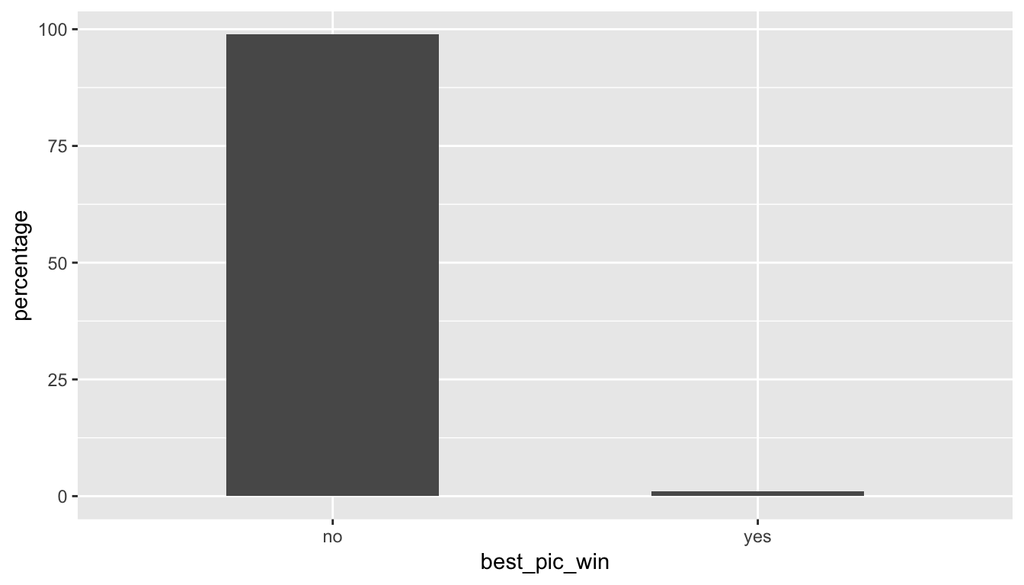

```r
ggplot(data = movies, aes(x = best_pic_win)) + geom_bar(aes(y = 100 *(..count..)/sum(..count..)), width = 0.5) + ylab('percentage')
```

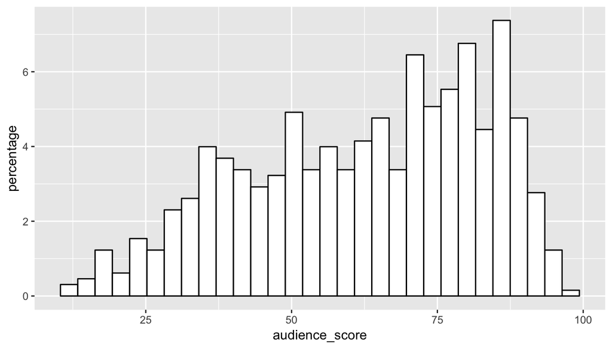

```r
ggplot(data = movies, aes(x = audience_score)) + geom_histogram(aes(y = 100*(..count..)/sum(..count..)), color = 'black', fill = 'white', bindwidth = 10) + ylab('percentage')
```

At a glance we suspect some features to have little to no association with our response variables. For instance, theater release date, dvd release year, url info, etc. do not bear any relation with audience_score or best_pic_win.

Let’s look at some features that might be of interest. First we start with numerical variables.

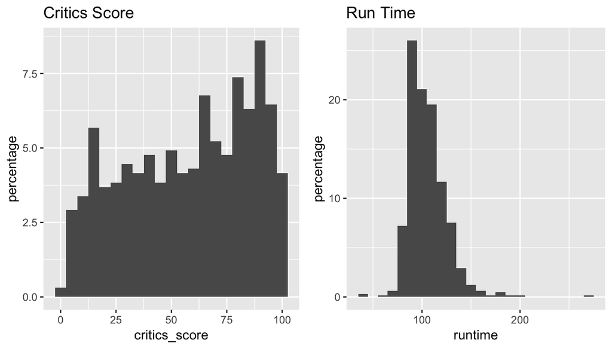

```r
c1 <- ggplot(data = movies, aes(x = critics_score)) + geom_histogram(aes(y = 100*(..count..)/sum(..count..)), binwidth = 5) + ylab('percentage') + ggtitle('Critics Score')

c2 <- ggplot(data = movies, aes(x = runtime)) + geom_histogram(aes(y = 100*(..count..)/sum(..count..)), binwidth =10) + ylab('percentage') + ggtitle('Run Time')

grid.arrange(c1, c2, ncol = 2)
```

While the first histogram for critics_score is remarkably similar to the variable audience_score, runtime has a distribution which is right-skewed.

Now let’s look at the imdb features: imdb_num_votes and imdb_rating.

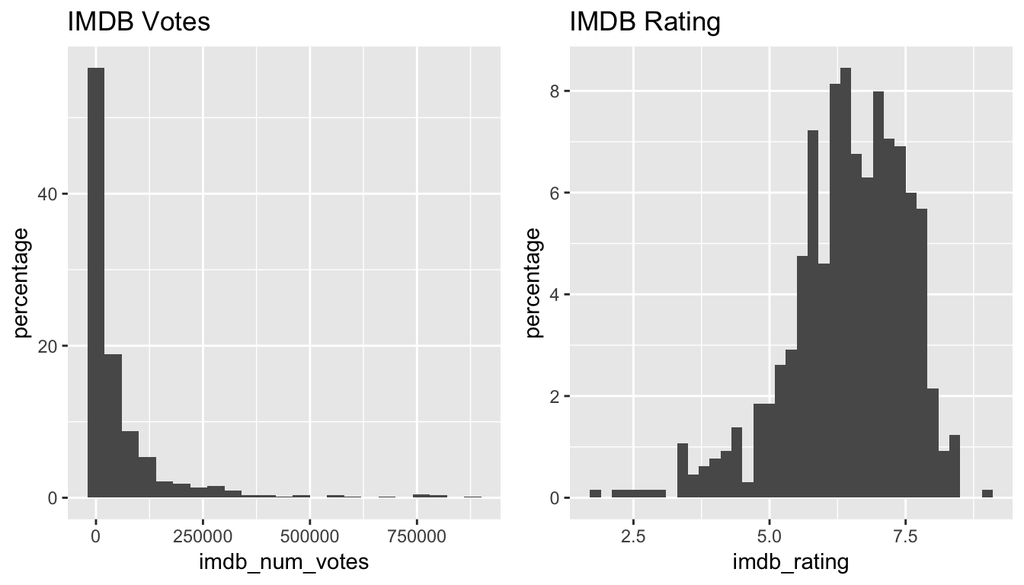

```r
c1 <- ggplot(data = movies, aes(x = imdb_num_votes)) + geom_histogram(aes(y = 100 * (..count..)/sum(..count..)), binwidth = 40000) + ylab('percentage') + ggtitle('IMDB Votes')

c2 <- ggplot(data = movies, aes(x = imdb_rating)) + geom_histogram(aes(y = 100* (..count..)/sum(..count..)), binwidth = 0.2) + ylab('percentage') + ggtitle('IMDB Rating')

grid.arrange(c1, c2, ncol = 2)
```

These two histograms we just plotted give us an idea of the relationship between number of votes and rating. Movies that receive a significantly high number of votes tend to be popular and are rated favorably (i.e. attain an average score of 70 or above).

We are interested in whether there is an observable difference in audience_score across genres. We explore this question using a boxplot.

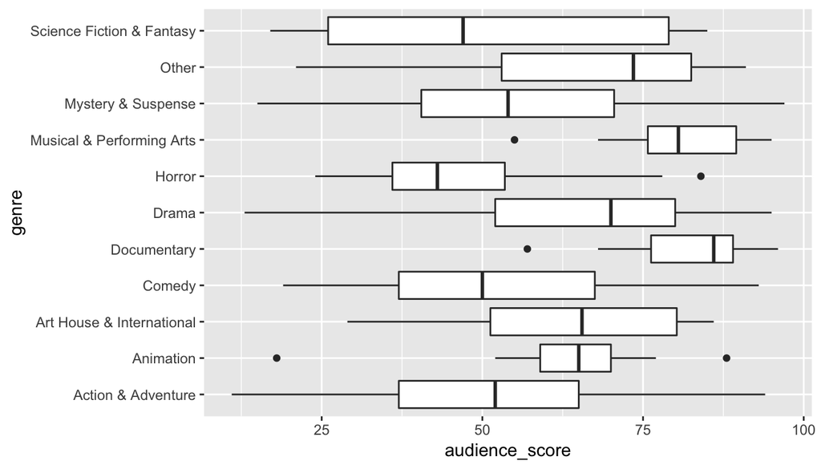

```r
ggplot(data = movies, aes(x = genre, y = audience_score)) + geom_boxplot() + coord_flip()
```

Here we see that genres including Documentary and Musical & Peforming Arts have a relatively high audience_score whereas horror and comedy films tend not to. This tells us that genre is a good candidate as a predictor in our regression model.

Let’s look at some scatter plots. First, we plot best_pic_win against critics_score.

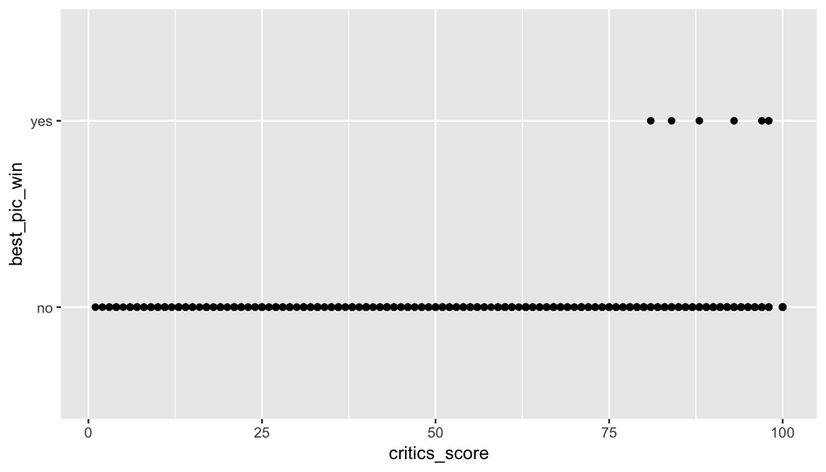

```r
ggplot(data = movies, aes(x = critics_score, y = best_pic_win)) + geom_point()
```

Here, we can see, roughly that, those movies who won best picture obtained a critics_score of at least about 80 points.

Now, let’s verify whether the critics_score has any correlation with runtime by plotting a scatter.

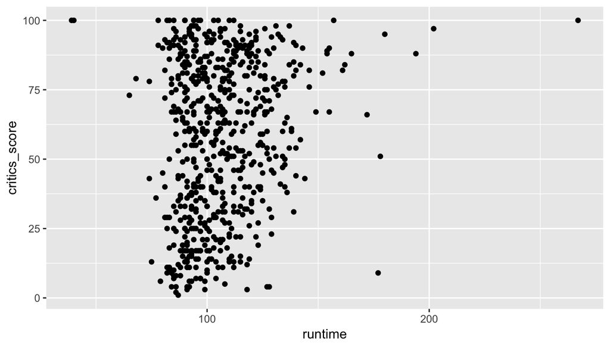

```r
ggplot(data = movies, aes(x = runtime, y = critics_score)) +
  geom_point()
```

Here it seems that there is a weak correlation between these two features. We verify our conclusion by looking at the correlation value.

```r
#the runtime column has a missing value, we find what index that belons to and remove it from the critics_score column

#find index
d <- movies$runtime
naind <- which(is.na(d))

#remove row corresponding to index
d2 <- movies[-c(naind),]

d <- d2$runtime
d1 <- d2$critics_score


cor(d, d1)
```

```
## [1] 0.1724989
```

We believe that critics_score has a positive correlation with audience_score. Let’s verify our assumption by looking at a scatter plot and the correlation value.

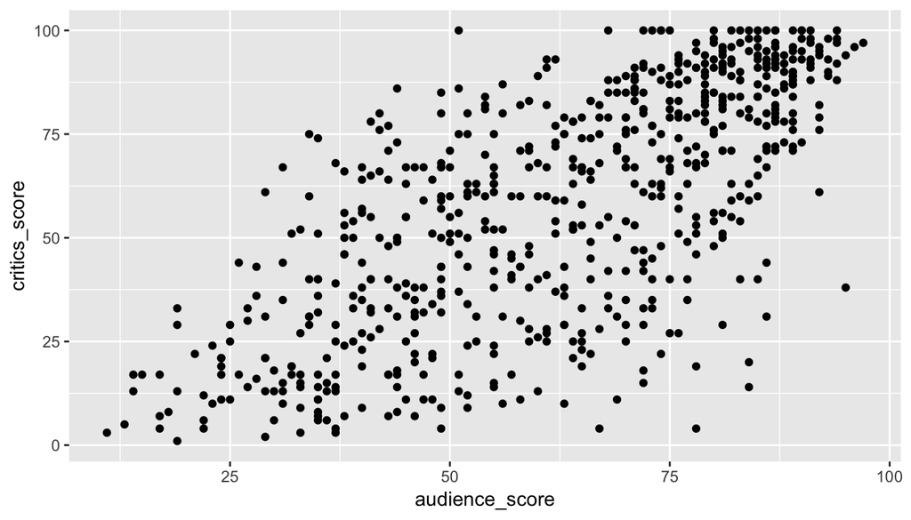

```r
ggplot(data = movies, aes(x = audience_score, y = critics_score)) +
  geom_point()
```

```r
corr <- cor(movies$audience_score, movies$critics_score)

print(corr)
```

```
## [1] 0.7042762
```

It seems that critics_score seems to be a good indicator of whether a movie will win best picture or not.

## Part 4: Modeling

We first fit our logistic regression model using the predictors: ‘critics_score’, ‘audience_score’, ‘genre’, ‘title_type’, ‘runtime’, ‘mpaa_rating’, ‘imdb_num_votes’, ‘best_pic_nom’, ‘best_actor_win’, and ‘best_actress_win’

```r
#get rid na values and mutate a new column won with value 1
#if a given a movie won best picture and 0 otherwise.

no_na <- movies %>%
  filter(!is.na(movies$best_pic_win)) %>%
  mutate(won = ifelse(best_pic_win == "yes", 1, 0)) %>%
  select(won, critics_score, audience_score, genre, title_type, runtime, mpaa_rating, imdb_num_votes, best_pic_nom , best_actor_win, best_actress_win)
```

Let’s see how our logistic regression does.

```r
logisticmodel <- glm(won~., family = binomial(link='logit'), data = no_na)
summary(logisticmodel)
```

```
##
## Call:
## glm(formula = won ~ ., family = binomial(link = "logit"), data = no_na)
##
## Deviance Residuals:
##      Min        1Q    Median        3Q       Max
## -1.76361  -0.00770  -0.00027   0.00000   2.24027
##
## Coefficients:
##                                  Estimate Std. Error z value Pr(>|z|)
## (Intercept)                    -7.527e+01  1.545e+04  -0.005   0.9961
## critics_score                   1.312e-01  1.130e-01   1.161   0.2455
## audience_score                 -1.815e-02  9.989e-02  -0.182   0.8558
## genreAnimation                  1.737e-01  2.130e+04   0.000   1.0000
## genreArt House & International  3.197e+00  1.530e+04   0.000   0.9998
## genreComedy                     1.911e+01  6.476e+03   0.003   0.9976
## genreDocumentary                1.193e+01  9.080e+03   0.001   0.9990
## genreDrama                      1.729e+01  6.476e+03   0.003   0.9979
## genreHorror                     2.737e+00  1.265e+04   0.000   0.9998
## genreMusical & Performing Arts -8.166e-01  1.795e+04   0.000   1.0000
## genreMystery & Suspense         1.247e+01  6.476e+03   0.002   0.9985
## genreOther                     -5.700e+00  1.604e+04   0.000   0.9997
## genreScience Fiction & Fantasy -6.231e+00  2.003e+04   0.000   0.9998
## title_typeFeature Film          1.468e+01  6.354e+03   0.002   0.9982
## title_typeTV Movie              1.672e+00  2.497e+04   0.000   0.9999
## runtime                         1.193e-01  6.205e-02   1.923   0.0545 .
## mpaa_ratingNC-17               -3.334e-01  5.729e+04   0.000   1.0000
## mpaa_ratingPG                   1.620e+01  1.250e+04   0.001   0.9990
## mpaa_ratingPG-13                6.310e+00  1.250e+04   0.001   0.9996
## mpaa_ratingR                    1.271e+01  1.250e+04   0.001   0.9992
## mpaa_ratingUnrated             -2.691e-01  1.400e+04   0.000   1.0000
## imdb_num_votes                  3.771e-06  3.909e-06   0.965   0.3347
## best_pic_nomyes                 3.693e+00  1.615e+00   2.287   0.0222 *
## best_actor_winyes              -3.276e+00  2.323e+00  -1.410   0.1585
## best_actress_winyes             1.447e+00  1.954e+00   0.740   0.4590
## ---
## Signif. codes:  0 '***' 0.001 '**' 0.01 '*' 0.05 '.' 0.1 ' ' 1
##
## (Dispersion parameter for binomial family taken to be 1)
##
##     Null deviance: 77.359  on 649  degrees of freedom
## Residual deviance: 18.357  on 625  degrees of freedom
##   (1 observation deleted due to missingness)
## AIC: 68.357
##
## Number of Fisher Scoring iterations: 22
```

```r
suppressWarnings(anova(logisticmodel, test = "Chisq"))
```

```
## Analysis of Deviance Table
##
## Model: binomial, link: logit
##
## Response: won
##
## Terms added sequentially (first to last)
##
##
##                  Df Deviance Resid. Df Resid. Dev  Pr(>Chi)
## NULL                               649     77.359
## critics_score     1  15.0086       648     62.351 0.0001070 ***
## audience_score    1   1.6458       647     60.705 0.1995354
## genre            10   8.8487       637     51.856 0.5465221
## title_type        2   0.6645       635     51.192 0.7173193
## runtime           1  15.0777       634     36.114 0.0001032 ***
## mpaa_rating       5   3.0672       629     33.047 0.6896202
## imdb_num_votes    1   5.7996       628     27.247 0.0160301 *
## best_pic_nom      1   6.3516       627     20.896 0.0117278 *
## best_actor_win    1   1.9411       626     18.954 0.1635441
## best_actress_win  1   0.5978       625     18.357 0.4394007
## ---
## Signif. codes:  0 '***' 0.001 '**' 0.01 '*' 0.05 '.' 0.1 ' ' 1
```

```r
#let's fit a logistic model to a subset of our features

log_fit2 <- glm(won ~ critics_score+runtime+imdb_num_votes+audience_score, family = binomial(link = 'logit'), data = no_na)

summary(log_fit2)
```

```
##
## Call:
## glm(formula = won ~ critics_score + runtime + imdb_num_votes +
##     audience_score, family = binomial(link = "logit"), data = no_na)
##
## Deviance Residuals:
##     Min       1Q   Median       3Q      Max
## -1.2601  -0.1074  -0.0324  -0.0068   3.2900
##
## Coefficients:
##                  Estimate Std. Error z value Pr(>|z|)
## (Intercept)    -1.635e+01  5.504e+00  -2.971  0.00297 **
## critics_score   1.034e-01  6.125e-02   1.688  0.09135 .
## runtime         1.829e-02  1.168e-02   1.566  0.11741
## imdb_num_votes  4.387e-06  1.704e-06   2.574  0.01006 *
## audience_score  5.592e-03  5.322e-02   0.105  0.91632
## ---
## Signif. codes:  0 '***' 0.001 '**' 0.01 '*' 0.05 '.' 0.1 ' ' 1
##
## (Dispersion parameter for binomial family taken to be 1)
##
##     Null deviance: 77.359  on 649  degrees of freedom
## Residual deviance: 45.835  on 645  degrees of freedom
##   (1 observation deleted due to missingness)
## AIC: 55.835
##
## Number of Fisher Scoring iterations: 10
```

```r
suppressWarnings(anova(log_fit2, test = "Chisq"))
```

```
## Analysis of Deviance Table
##
## Model: binomial, link: logit
##
## Response: won
##
## Terms added sequentially (first to last)
##
##
##                Df Deviance Resid. Df Resid. Dev Pr(>Chi)
## NULL                             649     77.359
## critics_score   1  15.0086       648     62.351 0.000107 ***
## runtime         1   7.7225       647     54.628 0.005454 **
## imdb_num_votes  1   8.7818       646     45.846 0.003042 **
## audience_score  1   0.0112       645     45.835 0.915803
## ---
## Signif. codes:  0 '***' 0.001 '**' 0.01 '*' 0.05 '.' 0.1 ' ' 1
```

Now let’s fit our linear model.

```r
linear_model <- lm(audience_score ~. , data = no_na)

summary(linear_model)
```

```
##
## Call:
## lm(formula = audience_score ~ ., data = no_na)
##
## Residuals:
##     Min      1Q  Median      3Q     Max
## -36.102  -8.792   0.112   9.088  42.892
##
## Coefficients:
##                                  Estimate Std. Error t value Pr(>|t|)
## (Intercept)                     3.415e+01  7.059e+00   4.838 1.66e-06 ***
## won                            -8.702e+00  6.030e+00  -1.443  0.14945
## critics_score                   4.053e-01  2.282e-02  17.759  < 2e-16 ***
## genreAnimation                  4.388e+00  5.288e+00   0.830  0.40696
## genreArt House & International  8.466e+00  4.116e+00   2.057  0.04010 *
## genreComedy                     9.797e-01  2.275e+00   0.431  0.66684
## genreDocumentary                1.358e+01  5.399e+00   2.516  0.01213 *
## genreDrama                      4.065e+00  1.998e+00   2.035  0.04232 *
## genreHorror                    -7.216e+00  3.387e+00  -2.130  0.03353 *
## genreMusical & Performing Arts  1.368e+01  4.640e+00   2.948  0.00332 **
## genreMystery & Suspense        -2.907e+00  2.546e+00  -1.142  0.25403
## genreOther                      1.391e+00  3.868e+00   0.360  0.71928
## genreScience Fiction & Fantasy -7.070e+00  4.826e+00  -1.465  0.14338
## title_typeFeature Film          4.379e-01  5.068e+00   0.086  0.93116
## title_typeTV Movie             -5.017e+00  7.942e+00  -0.632  0.52782
## runtime                         2.542e-02  3.269e-02   0.778  0.43716
## mpaa_ratingNC-17               -1.110e+01  1.028e+01  -1.080  0.28042
## mpaa_ratingPG                  -2.111e+00  3.736e+00  -0.565  0.57227
## mpaa_ratingPG-13               -4.838e+00  3.850e+00  -1.257  0.20938
## mpaa_ratingR                   -2.731e+00  3.706e+00  -0.737  0.46157
## mpaa_ratingUnrated             -2.369e+00  4.259e+00  -0.556  0.57834
## imdb_num_votes                  3.491e-05  5.639e-06   6.191 1.09e-09 ***
## best_pic_nomyes                 7.094e+00  3.543e+00   2.002  0.04571 *
## best_actor_winyes              -1.291e+00  1.614e+00  -0.800  0.42398
## best_actress_winyes            -2.168e+00  1.786e+00  -1.214  0.22535
## ---
## Signif. codes:  0 '***' 0.001 '**' 0.01 '*' 0.05 '.' 0.1 ' ' 1
##
## Residual standard error: 13.54 on 625 degrees of freedom
##   (1 observation deleted due to missingness)
## Multiple R-squared:  0.569,  Adjusted R-squared:  0.5524
## F-statistic: 34.38 on 24 and 625 DF,  p-value: < 2.2e-16
```

Here, we see that the features: critics_score, genre, imdb_num_votes, and best_pict_nom are significant predictors for our linear model. Let’s fit a new model including just these. Just as we saw in our exploratory data analysis, genre is a significant feature in our model. For example, all held constant, if the movie genre is a musical, then there is an increase of 13.68 points in the audience_score, which is quite remarkable.

```r
lin_fit2 <- lm(audience_score~ critics_score+genre+imdb_num_votes+best_pic_nom, data = no_na)

summary(lin_fit2)
```

```
##
## Call:
## lm(formula = audience_score ~ critics_score + genre + imdb_num_votes +
##     best_pic_nom, data = no_na)
##
## Residuals:
##     Min      1Q  Median      3Q     Max
## -36.984  -8.714   0.106   9.275  43.653
##
## Coefficients:
##                                  Estimate Std. Error t value Pr(>|t|)
## (Intercept)                     3.404e+01  1.904e+00  17.882  < 2e-16 ***
## critics_score                   4.129e-01  2.178e-02  18.956  < 2e-16 ***
## genreAnimation                  5.780e+00  4.811e+00   1.201  0.23001
## genreArt House & International  8.340e+00  4.009e+00   2.080  0.03788 *
## genreComedy                     4.016e-02  2.223e+00   0.018  0.98559
## genreDocumentary                1.287e+01  2.757e+00   4.669 3.70e-06 ***
## genreDrama                      3.297e+00  1.913e+00   1.724  0.08526 .
## genreHorror                    -7.262e+00  3.291e+00  -2.207  0.02767 *
## genreMusical & Performing Arts  1.363e+01  4.334e+00   3.145  0.00174 **
## genreMystery & Suspense        -3.609e+00  2.447e+00  -1.475  0.14076
## genreOther                      1.266e+00  3.812e+00   0.332  0.73991
## genreScience Fiction & Fantasy -6.640e+00  4.808e+00  -1.381  0.16778
## imdb_num_votes                  3.308e-05  5.243e-06   6.310 5.22e-10 ***
## best_pic_nomyes                 4.427e+00  3.155e+00   1.403  0.16107
## ---
## Signif. codes:  0 '***' 0.001 '**' 0.01 '*' 0.05 '.' 0.1 ' ' 1
##
## Residual standard error: 13.51 on 637 degrees of freedom
## Multiple R-squared:  0.5627, Adjusted R-squared:  0.5537
## F-statistic: 63.04 on 13 and 637 DF,  p-value: < 2.2e-16
```

There is not much of a difference between R-squared values between our first and second model. Moreover, the second fit has a higher F-statistic than the first indicating that, jointly, the set of variables we chose for our second model are more significant than the underlying set. This doesn’t tell us much about the predictive power of our models but it does explain which one is more biased and which one has higher variance.

Let’s look at a plot of residuals to verify that we have a linear relationship between response and predictor variables.

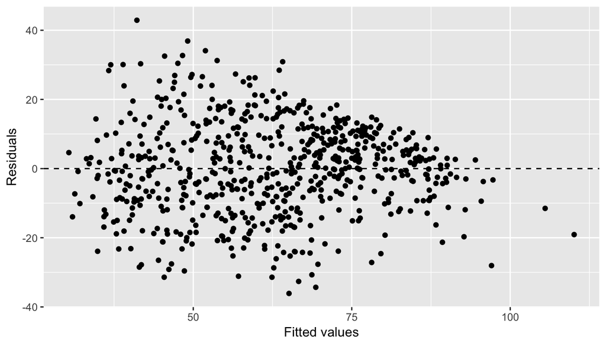

```r
ggplot(data = linear_model, aes(x = .fitted, y = .resid)) +
  geom_point() +
  geom_hline(yintercept = 0, linetype = "dashed") +
  xlab("Fitted values") +
  ylab("Residuals")
```

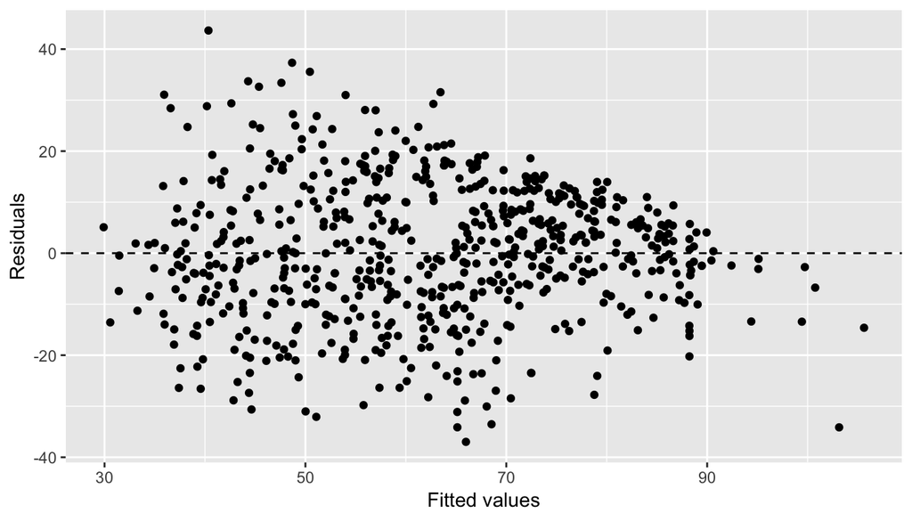

```r
ggplot(data = lin_fit2, aes(x = .fitted, y = .resid)) +
  geom_point() +
  geom_hline(yintercept = 0, linetype = "dashed") +
  xlab("Fitted values") +
  ylab("Residuals")
```

The residuals are equally distributed about the line y = 0 for both fits. So the answer is yes.

## Part 5: Prediction

We use a pscl package developed by Simon Jackman in order to see how well our logistic model performed.

```r
library(pscl)
library(Metrics)

pR2(logisticmodel)
```

```
##          llh      llhNull           G2     McFadden         r2ML
##  -9.17830425 -38.69042642  59.02424435   0.76277583   0.08680563
##         r2CU
##   0.77343201
```

```r
pR2(log_fit2)
```

```
##          llh      llhNull           G2     McFadden         r2ML
## -22.91755974 -38.69042642  31.54573337   0.40766846   0.04737305
##         r2CU
##   0.42209049
```

Finally, let’s extrapolate. Consider the movie “Moonlight” which came out in 2016. Let’s see whether our models correctly predict this movie winning best picture and also the audience score, which according to Rotten Tomatoes, is 79.

```r
#predictor values for the movie "Moonlight"
won <- c(1)
critics_score <- c(98.0)
audience_score <- c(79.0)
genre <- c('Drama')
title_type <- c('Feature Film')
runtime <- c(111)
mpaa_rating <- c('R')
imdb_num_votes <- c(218348)
best_pic_nom <- c('yes')
best_actor_win <- c('no')
best_actress_win <- c('no')

original_linreg <- data.frame(won, critics_score, genre, title_type, runtime, mpaa_rating, imdb_num_votes, best_pic_nom, best_actor_win, best_actress_win)

original_logreg <- data.frame(critics_score, genre, title_type, runtime, mpaa_rating, imdb_num_votes, best_pic_nom, best_actor_win, best_actress_win)

moonlight_logreg <- data.frame(critics_score, runtime, imdb_num_votes, audience_score)

moonlight_linreg <- data.frame(critics_score, genre, imdb_num_votes, best_pic_nom)

#best picture win prediction using original model
print(predict(logisticmodel, newdata = original_logreg, type = 'response'))
```

```
##         1
## 0.1973548
```

```r
#best picture win prediction using fit2
print(predict(log_fit2, newdata = moonlight_logreg, type = 'response'))
```

```
##          1
## 0.05799329
```

```r
#audience score prediction using original model

#95 percent confidence interval
print(predict(linear_model, newdata = original_linreg, interval = 'confidence', level = 0.95))
```

```
##        fit      lwr      upr
## 1 84.47599 73.76256 95.18941
```

```r
#audience score prediction using fit2

#95 percent confidence interval
print(predict(lin_fit2, newdata = moonlight_linreg, interval = 'confidence', level = 0.95))
```

```
##        fit      lwr      upr
## 1 89.46029 83.72576 95.19482
```

```r
#99 percent confidence interval
print(predict(lin_fit2, newdata = moonlight_linreg, interval = 'confidence', level = 0.997))
```

```
##        fit     lwr      upr
## 1 89.46029 80.7602 98.16037
```

Looking at the original linear model, 95 percent of rows such as “Moonlight” will have a score between 73.76 and 95.19. This confidence interval indeed includes the actual audience_score value of 79. However, at 95 percent confidence, our second fit does not include 79. But, if we increase our confidence level to 99.7 we obtain a lower bound of 80.76 which is quite close to the actual score. This suggests that the variance of our prediction increases as we add more features to our linear model.

## Part 6: Conclusion

In retrospect, adding additional features such as Golden Awards information to our dataframe would improve our linear model accuracy and reduce variance in our predicted values.